# Lab 3: Understanding the General Update Pattern

CMSC471: Introduction to Information Visualization (Spring 2026)

**Grade (3% of total course grade)**: This lab is graded out of 30 points. You may submit your lab in person during the lab session on Wednesday, Feb 25, 2026 or during any office hours. The final submission deadline is Thursday, Feb 26, 2026 at 6:00 PM (ET).

In this lab, you’ll learn how D3’s General Update Pattern works by creating an interactive scatterplot that can handle dynamic data changes.

The core concept in D3’s General Update Pattern is still “data binding”—connecting data elements to DOM elements. When data changes, D3 helps us manage three scenarios:

- `enter`: New data points need new visual elements
- `update`: Existing data points need their visual elements modified
- `exit`: Data points that no longer exist need their visual elements removed

```
data:    [A, B, C]
DOM:     [A, B, C]  (circles on screen)
         ↑ bound together through data joins

enter:   new data arrives that wasn't previously bound
data:    [A, B, C, D, E]
DOM:     [A, B, C]
         enter → [D, E]  (new circles needed)

update:  existing data changes values
data:    [A', B', C]     (same elements, new values)
DOM:     [A,  B,  C]
         update → update positions/attributes of existing circles

exit:    Data is removed
data:    [A, B]
DOM:     [A, B, C]
         exit → [C]      (remove unneeded circle)
```

The basic visualization idiom we use is a scatterplot. We will have three buttons on the interface, one to add a data point, one to remove a data point, and one to move all data points. When we click on a button, the scatterplot will be updated accordingly.

You can decide **how many** data points to add/remove/move, and **how** you move them (e.g., the distance/direction).

## Part 1: Setup

Let’s first set up the structure of our lab.

### Project structure

1. Locate your `CMSC471` folder.
2. Copy your `lab2/` into `lab3/`. Change the lab name in `index.html` to “Lab 3: Understanding the General Update Pattern”.
3. Add a `data/` folder with a `data.json`.

```
lab3/
├── index.html
├── css/
│   └── styles.css
├── js/
│   └── script.js
└── data/
    └── data.json
```

The content of the `data.json` should be

```json
{
    "points": [
      {"id": 1, "x": 30, "y": 50, "color": "orange"},
      {"id": 2, "x": 70, "y": 80, "color": "steelblue"},
      {"id": 3, "x": 45, "y": 60, "color": "orange"},
      {"id": 4, "x": 65, "y": 40, "color": "steelblue"}
    ]
  }
```

4. Start a local server:
   - VS Code extension “Live Server”: Click on `Go Live` and it should automatically open a browser for you
   - Python 3: `python -m http.server 8000`; visit: `http://localhost:8000`

### Modifying your code

1. In your `index.html`, we need something on the interface to trigger different changes. So let’s add three buttons on the top of the visualization.

```html
 <div class="controls">
 <button id="addPoint">Add Point</button>
 <button id="removePoint">Remove Point</button>
 <button id="updatePoints">Update Points</button>
 </div>
 <div id="vis"></div> <!--  Will hold our visualization (SVG) -->
```

2. Open your `script.js`. Delete other code but keep those specifying **margins**, `svg` and `g`, **scales**, and **axes**.

   **Why**: We are going to have a different visualization with different visual encodings. But we still need an SVG canvas and similar scales/axes.

   Depending on your browser and OS, your buttons may look different. We will also provide code to modify buttons at the end.

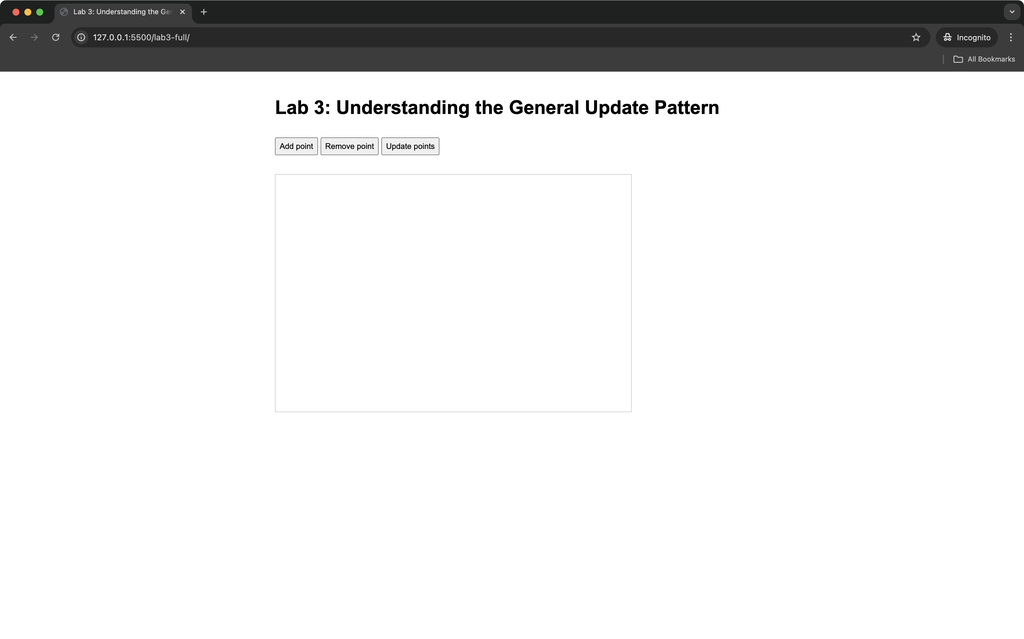

   Here, our example uses [Bootstrap](https://getbootstrap.com/docs/5.3/components/buttons/#base-class) buttons for aesthetics purposes.

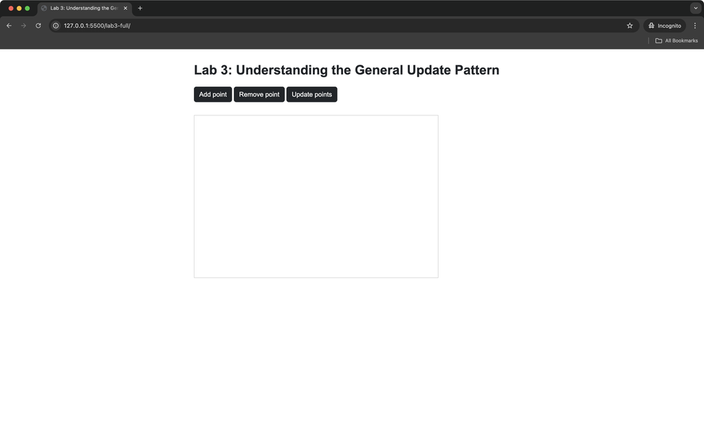

   Result of Part 1 Step 2

3. One last thing. This time our x-axis is a quantitative variable. We need to replace `scaleBand()` with `scaleLinear()`. Note that we will add or remove data points in this lab. So instead of the largest values, we use a predefined data range `[0, 100]` for both x and y axes. You code should look like

```javascript
  // Specify margin
  // [copied from lab 2]

  // Create svg and g
  // [copied from lab 2]

  // Create scales
  const xScale = d3.scaleLinear() // a numeric / quantative scale
    .domain([0, 100]) // prefined data range
    .range([0, width]);

  const yScale = d3.scaleLinear()
  .domain([0, 100]) // prefined data range
  .range([height, 0]);

  // Add axes
  // [copied from lab 2]
```

So, you should be able to see

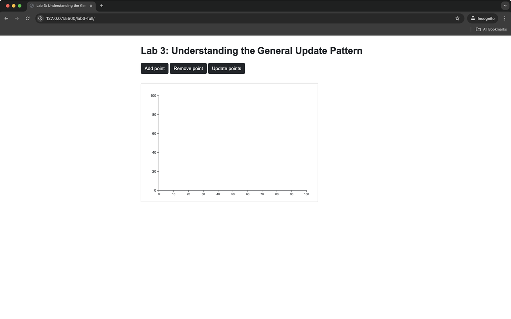

Result of Part 1 Step 3

## Part 2: Creating the initial scatterplot

We first load data in `script.js`. D3 provides a handy function for loading data.

### Loading and displaying data

```javascript
let currentData = []; // global variable

d3.json('data/data.json')
    //callback function
    .then(data => {
        console.log(data)
        currentData = data.points
        updateVis()
    })
    .catch(error => console.error('Error loading data:', error))

function updateVis(){
  // right now, we don't know this function. So let's leave this blank
}
```

Remember to use `Developer Tools` (Inspect) to check whether the data is loaded!

[figure not shown]

Result of Part 2 Step 1

### Creating a scatterplot

Next, we need to think about this core function `updateVis`. We have four data behaviors:

- When first loading the dataset, we need to bind each data point to a `circle`
- Similarly, when addinng new data points (within [0, 100]), we need to bind these new data points to new `circle`s
- We may move data points. In other words, the attributes (e.g., `cy`, `cx`) associated with the circle SVG elements might change
- Remove the last data point (or a random data point) in the array `currentData`, we need to remove the binding

The `.join()` function is D3’s newest way to handle all three data scenarios (Note you could also use this function in Lab 2):

- `enter`: Creates new DOM elements for new data points
- `update`: Modifies existing DOM elements when their data changes
- `exit`: Removes DOM elements when their data is gone

The .data() function performs the “data join” - it matches data array elements to DOM elements using a key function (by default, **array index**).

```javascript
function updateVis(){
   // Now, the class point is important.
   // To make sure we can manipulate circles, we need to select all .point elements.
   // And thus, all circles created should have this class name (see below).
   svg.selectAll('.point')
   // using the global variable
   .data(currentData)
   .join(
        function(enter){ },
        function(update){ },
        function(exit){ }
   )
}
```

or a different way is to use arrow function definitions

```javascript
function updateVis(){
   svg.selectAll('.point')
   // using the global variable
   .data(currentData)
   .join(
        enter => { },
        update => { },
        exit => { }
   )
}
```

At this point, at least we know what to do when we first load data. So we can write the `enter` function. This is a combination of what you learn form Lab 1 (`circle`) and Lab 2 (**data binding**).

```javascript
function(enter){
    return  enter
    .append('circle')
    .attr('cx', d => xScale(d.x))
    .attr('cy', d => yScale(d.y))
    .attr('r', 5)
    .style('fill', d => d.color)
    // Important. All new circles should be associated with the point class
    .attr('class', 'point')
  }
```

The `enter` function handles new data points. When called, it:  
1. Gets a selection of “placeholder” elements for new data  
2. For each placeholder, appends actual DOM elements (circles of the `point` class / `.point`)  
3. Sets initial attributes based on the data  
4. Returns the new elements for any additional modifications

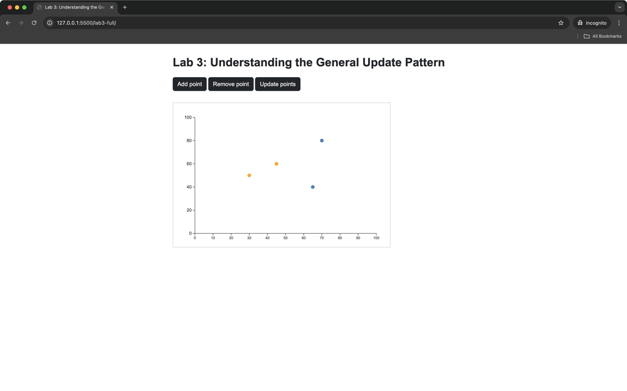

Result of Part 2 Step 2

## Part 2: Implementing the dynamic scatterplots

### Defining data changes

We now first define data changes.

If we add a data point, we generate their x and y coordindates randomly.

```javascript
function addRandomPoint() {
    // make it easier for debugging
    console.log('add point')
    const newPoint = {
        x: // finish the code, generate a number between 0 - 100
        y: // finish the code, generate a number between 0 - 100
        color: 'red'
    };
    currentData.push(newPoint);
    // call to update visualization
    updateVis();
}
```

If we remove a point,

```javascript
function removeRandomPoint() {
    // make it easier for debugging
    console.log('remove point')
    currentData.pop();
    // call to update visualization
    updateVis();
}
```

If we move the points around, we add offsets to their x and y coordinates.

```javascript
function updateRandomPoints() {
    // make it easier for debugging
    console.log('update points')
    currentData = currentData.map(d => ({
        id: currentData.length + 1,
        x: // finish the code, move d.x a bit
        y: // finish the code, move d.y a bit
    }));
    // call to update visualization
    updateVis();
}
```

### Defining visual element changes

Now we have a better idea about data behavior. So we come back and define the responding changes of visual elements. Let’s work on `.join` again.

The `update` function handles existing elements when their data changes:  
1. Receives a selection of existing DOM elements  
2. Updates their attributes based on new data values  
3. Can add transitions/animations for smooth updates (optional)

```javascript
// We know we want to changes their coordinates
function(update){
  return  update
    .attr('cx', d => xScale(d.x))
    .attr('cy', d => yScale(d.y))
}
```

The exit function handles elements whose data has been removed: 1. Receives a selection of DOM elements no longer needed  
2. Can add transitions for smooth removal (optional)  
3. Removes elements from the DOM

```javascript
// We know we want to remove an element if its associated data point is removed
function(exit){
  return  exit.remove()
}
```

The `enter()` will take care all new points. So we don’t need to add anything.

Nothing happens? Wait! We need to tell the buttons what to do.

### Adding event listeners

You can add listeners to buttons in D3.

```javascript
d3.select('#addPoint')
    .on('click', addRandomPoint);

d3.select('#removePoint')
    .on('click', removeRandomPoint);

d3.select('#updatePoints')
    .on('click', updateRandomPoints);
```

Or you can add listeners to buttons in `index.html`. But don’t do both.

```html
<button id="addPoint" onClick=addRandomPoint()>Add point</button>
<button id="removePoint" onClick=removeRandomPoint()>Remove point</button>
<button id="updatePoints" onClick=updateRandomPoints()>Update points</button>
```

Now you are ready to go!

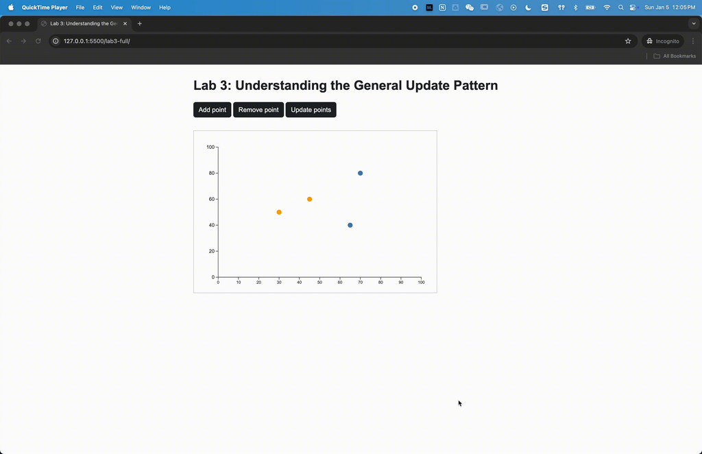

Result of Part 2

## Part 3: Add transitions and miscs (required)

Now it’s your time to explore it a bit. Please add at least **one animated transition** (there are three in total: add, update, remove) and at least **one feature that improves presentation** (a paragraph, pretty buttons, or other).

### Animated transitions

One thing nice about D3 is that it lets you create animation easily. While we will learn these in the next D3 lab, you can read the transition documentation https://www.d3indepth.com/transitions/ for a bite.

Hint: you only need to add about 10 lines for three transitions (about 2-5 lines for each of `enter`, `update`, and `exit`). In our example, when add and remove points, the radius of the circle always start with / shrink to 0. However, you can define a different animation behavior that makes sense. Also, it is possible to finish this in CSS.

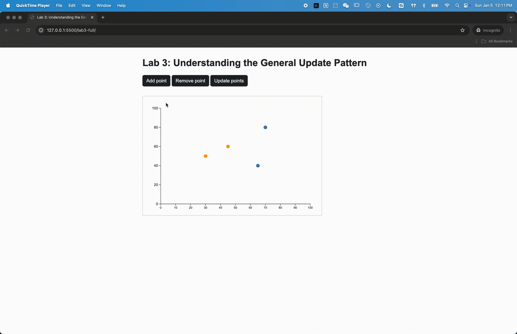

Result of transition

### More explanation

You can make up a cover story for your visualization 1. Add labels to x and y axis (Hint: your Lab 2)  
2. Add a `<p>` to describe the data/visualization

### Beautifying buttons

Here are sample code to tweak your buttons. Put them into `css/styles.css`.

```css
button {
    padding: 8px 16px;
    margin-right: 10px;
}
```

Alternatively, you can also explore [bootstrap.js](https://getbootstrap.com/docs/4.0/components/buttons/) buttons.

Hint: you need to add a line to `index.html` and modify the class names of your buttons.

```javascript
<link href="https://cdn.jsdelivr.net/npm/bootstrap@5.3.3/dist/css/bootstrap.min.css" rel="stylesheet" integrity="sha384-QWTKZyjpPEjISv5WaRU9OFeRpok6YctnYmDr5pNlyT2bRjXh0JMhjY6hW+ALEwIH" crossorigin="anonymous">
```

### Specifying the keys (don’t count)

For a better practice, we can specify the keys explicitly. See https://d3js.org/d3-selection/joining.

> If a key function is not specified, then the first datum in data is assigned to the first selected element, the second datum to the second selected element, and so on. A key function may be specified to control which datum is assigned to which element, replacing the default join-by-index, by computing a string identifier for each datum and element.

```
    ...
    .data(data, d => d.id)
    .join(
        ...
    )
```

## Checklist ✓

- The initial scatterplot is showing
- Add button creates new points
- Remove button remove a point
- Update button moves points
- No console errors
- At least one animated transition
- At least one feature to improve the presentation

**Submission process**

- Raise your hand ✋
- Show the working webpage (a scatterplot, three buttons, add/remove/update, one animation, one presentation)
- Let us skim your `script.js` and `console`
- Any additional features implemented
- Confirm your name

### AI usage

- **Permitted uses**: AI tools may be used for brainstorming, generating ideas, improving writing clarity, debugging code, and explaining concepts or code snippets.
- **Prohibited uses for labs**: Using AI tools to directly complete labs is strictly prohibited. If such use is identified, the corresponding lab will receive a 66% score reduction and no further submission for this lab will be accepted.
- **Conceptual understanding checks**: During lab checkouts, we will ask conceptual questions related to the lab to ensure understanding. Repeated inability to answer these questions will result in an additional 33% deduction.

## Troubleshooting

### 1. Points not appearing

- Check data loading (console.log data)
- Verify scale domains
- Check SVG dimensions
- Confirm point coordinates

### 2. Points not updating

- Check data binding key function
- Verify update selection
- Console.log data changes

### 3. Axes issues

- Verify scale domains update
- Check axis orientation
- Confirm margin conventions

## Resources

- [D3 Scale Documentation](https://github.com/d3/d3-scale)
- [SVG Rectangle Reference](https://developer.mozilla.org/en-US/docs/Web/SVG/Element/rect)
- [D3 Enter, Exit and Update](https://www.d3indepth.com/enterexit/)